# **Curso de Estadística básica para Data Scientists**

Dae-Jin Lee < lee.daejin@gmail.com >

TEMA 5. Inferencia Estadística

[Regresar a la página principal](https://idaejin.github.io/bcam-courses/R/datahack/)

# 1 Inferencia Estadística

La inferencia estadística permite obtener conclusiones a partir de los datos. Hay muchas maneras de realizar inferencia incluyendo la modelización estadística, estrategias orientadas a datos y uso explícito de diseños y aleatorización en análisis de datos. Además, existen teorías amplias (frecuencias, bayesianas, verosimilitud, , …) y numerosas dificultades (datos faltantes, sesgos) para realizar la inferencia. Este tema presenta los fundamentos de la inferencia en un enfoque práctico, con el fin de utilizar la inferencia estadística para tomar decisiones informadas en el análisis de datos.

## 1.1 Estimación por intervalos

Es un requisito común para estimar eficientemente los parámetros de población basados en datos de muestras aleatorias simples.

```r
library(MASS)
?survey
head(survey)
```

```
##      Sex Wr.Hnd NW.Hnd W.Hnd    Fold Pulse    Clap Exer Smoke Height
## 1 Female   18.5   18.0 Right  R on L    92    Left Some Never 173.00
## 2   Male   19.5   20.5  Left  R on L   104    Left None Regul 177.80
## 3   Male   18.0   13.3 Right  L on R    87 Neither None Occas     NA
## 4   Male   18.8   18.9 Right  R on L    NA Neither None Never 160.00
## 5   Male   20.0   20.0 Right Neither    35   Right Some Never 165.00
## 6 Female   18.0   17.7 Right  L on R    64   Right Some Never 172.72
##        M.I    Age
## 1   Metric 18.250
## 2 Imperial 17.583
## 3     <NA> 16.917
## 4   Metric 20.333
## 5   Metric 23.667
## 6 Imperial 21.000
```

**Estimación puntual de la media poblacional**

Para cualquier muestra aleatoria en particular, siempre podemos calcular la media muestral. Aunque la mayoría de las veces no es la media real de la población, sirve como una buena estimación puntual. Por ejemplo, en los datos `survey`, la encuesta se realiza sobre una muestra de la población estudiantil. Podemos calcular la media de la muestra y utilizarla como una estimación del parámetro de población correspondiente.

**Ejercicio:** Encuentra una estimación puntual de la altura media de los estudiantes universitarios con los datos de la muestra de la encuesta.

```r
mean(survey$Height)
```

```
## [1] NA
```

```r
mean(survey$Height,na.rm=TRUE)
```

```
## [1] 172.3809
```

```r
# or
mean(na.omit(survey$Height))
```

```
## [1] 172.3809
```

Una vez calculada uns estimación puntual de la media de la población, necesitaríamos una manera de cuantificar su exactitud.

### 1.1.1 Intervalo para la estimación de la media poblacional (con varianza conocida)

**Ejercicio:** supongamos una población de desviación típica $\sigma$ de las alturas de la encuesta es 9.48. Calcula el margen de error y la estimación del intervalo de confianza del 95%.

```r
x <- na.omit(survey$Height)
n <- length(x)
sigma <- 9.48
sem = sigma/sqrt(n)  # Standard error of the mean
sem
```

```
## [1] 0.6557453
```

Dado que hay dos colas de la distribución normal, el nivel de confianza del 95% implicaría el percentil 97.5 de la distribución normal en la cola superior. Por tanto, $z_{\alpha/2}$ viene dado por `qnorm(.975)`. Lo multiplicamos con el error estándar de la media `sem` y obtenemos el margen de error.

```r
E <- qnorm(0.975)*sem
E  # margin of error
```

```
## [1] 1.285237
```

```r
xbar <- mean(x,na.rm = TRUE)
xbar + c(-E,E)
```

```
## [1] 171.0956 173.6661
```

De manera alternativa, podemos utilizar `z.test`

```r
library(TeachingDemos)
z.test(x,sd=sigma)
```

```
##
##  One Sample z-test
##
## data:  x
## z = 262.88, n = 209.00000, Std. Dev. = 9.48000, Std. Dev. of the
## sample mean = 0.65575, p-value < 2.2e-16
## alternative hypothesis: true mean is not equal to 0
## 95 percent confidence interval:
##  171.0956 173.6661
## sample estimates:
## mean of x
##  172.3809
```

Suponiendo que la desviación estándar de la población $\sigma$ sea 9.48, el margen de error para la encuesta de altura del estudiante al nivel de confianza del 95% es 1.2852372 centímetros. El intervalo de confianza está entre 171.095624 y 173.6660984 centimetros.

### 1.1.2 Intervalo para la estimación de la media poblacional (con varianza desconocida)

```r
s = sd(x)
SE <- s/sqrt(n)
E = qt(.975, df=n-1)*SE; E
```

```
## [1] 1.342878
```

```r
xbar + c(-E, E)
```

```
## [1] 171.0380 173.7237
```

```r
# or

t.test(x)
```

```
##
##  One Sample t-test
##
## data:  x
## t = 253.07, df = 208, p-value < 2.2e-16
## alternative hypothesis: true mean is not equal to 0
## 95 percent confidence interval:
##  171.0380 173.7237
## sample estimates:
## mean of x
##  172.3809
```

Sin el suepuesto sobre la desviación estándar de la población, el margen de error para la encuesta de altura del estudiante a un nivel de confianza del 95% es de 1.3429 centímetros. El intervalo de confianza está entre 171.04 y 173.72 centímetros.

#### 1.1.2.1 Tamaño muestral de la media poblacional

La calidad de una encuesta muestral puede mejorarse aumentando el tamaño de la muestra. La fórmula siguiente proporciona el tamaño de muestra requerido bajo el requisito de estimación del intervalo medio de la población a $(1-\alpha)$ nivel de confianza, margen de error $E$ y varianza poblacional $\sigma^2$. Aquí, $z_{\alpha-2}$ es el percentil $100 (1 -\alpha/2)$ de la distribución normal estándar.

$$n = \frac{(z_{\alpha/2})^2 \sigma^2}{E^2}$$

**Ejercicio:**

Supongamos que la desviación estándar de la población $\sigma$ de la altura del estudiante en `survey` es 9.48. Encuentre el tamaño de muestra necesario para lograr un margen de error de 1,2 centímetros a un nivel de confianza del 95%.

```r
zstar = qnorm(.975)
sigma = 9.48
E = 1.2
zstar^2 *sigma^2/ E^2
```

```
## [1] 239.7454
```

Basándonos en la suposición de que la desviación estándar de la población es de 9,48, necesita un tamaño de muestra de 240 para lograr un margen de error de 1,2 centímetros con un nivel de confianza del 95%.

### 1.1.3 Estimación de intervalos de confianza para la proporción poblacional

**Estimación puntual de la proporción poblacional**

Los cuestionarios de opción múltiple en una encuesta se usan a menudo para determinar la proporción de una población con ciertas características. Por ejemplo, podemos estimar la proporción de estudiantes femeninas en la universidad sobre la base del resultado en el conjunto de datos de muestra `survey`.

**Ejercicio:** Calcula una estimación puntual de la proporción de estudiantes femeninos de la encuesta.

```r
library(MASS)
gender.response <- na.omit(survey$Sex) # filter out NA's
n <- length(gender.response)
table(gender.response)
```

```
## gender.response
## Female   Male
##    118    118
```

Para averiguar el número de mujeres estudiantes, comparamos `gender.response`

```r
k <- sum(gender.response == "Female")
# or
k <- table(gender.response)[1]

pbar <- k/n; pbar
```

```
## Female
##    0.5
```

La estimación puntual de la proporción de estudiantes femeninas en la encuesta es del 50%.

Con el fin de calcular el intervalo de confianza de la proporción estimada, denotemos el percentil $100(1-\alpha/2)$ de la distribución normal estándar como $z_{\alpha/2}$. Si el tamaño de las muestras $n$ y la proporción de la población $p$ satisfacen la condición de que $np \geq 5$ y $n (1-p) \geq 5$, que los puntos finales de la estimación del intervalo en $(1-\alpha)$ se define el nivel de confianza en términos de la proporción de la muestra como sigue.

$$\bar{p} = \pm z_{\alpha/2} \sqrt{\frac{\bar{p}(1-\bar{p})}{n}}$$

Utilizaremos `prop.test`

```r
prop.test(k,n,conf.level = 0.95)
```

```
##
##  1-sample proportions test without continuity correction
##
## data:  k out of n, null probability 0.5
## X-squared = 0, df = 1, p-value = 1
## alternative hypothesis: true p is not equal to 0.5
## 95 percent confidence interval:
##  0.4367215 0.5632785
## sample estimates:
##   p
## 0.5
```

#### 1.1.3.1 Tamaño muestral de la proporción de la población

La calidad de una encuesta muestral puede mejorarse aumentando el tamaño de la muestra. La siguiente fórmula proporciona el tamaño de muestra requerido bajo el requisito de estimación de intervalo de proporción de poblacion a $(1-\alpha)$ nivel de confianza, margen de error $E$, y estimación de proporción planeada $p$. Aquí, $z_{\alpha/2}$ es el percentil $100(1-\alpha/2)$ de la distribución normal estándar.

$$n = \frac{(z_{\alpha/2})^2 p (1-p)}{E^2}$$

```r
zstar = qnorm(.975)
p = 0.5
E = 0.05
zstar^2 * p * (1-p) / E^2
```

```
## [1] 384.1459
```

With a planned proportion estimate of 50% at 95% confidence level, it needs a sample size of 385 to achieve a 5% margin of error for the survey of female student proportion.

## 1.2 Inferencia sobre dos poblaciones

A menudo es necesario sacar conclusiones sobre la diferencia entre dos poblaciones por sus muestras de datos. En los siguientes tutoriales, discutimos cómo estimar la diferencia de medios y proporciones entre dos poblaciones de datos distribuidos normalmente.

### 1.2.1 Media de población entre dos muestras

Se comparan dos muestras de datos si proceden de observaciones repetidas del mismo sujeto. Aquí, suponemos que las poblaciones de datos siguen la distribución normal. Usando un test-t para muestras pareadas (*paired t-test*), podemos obtener una estimación de intervalo de la diferencia de los medios de población.

```r
library(MASS)
data(immer)
?immer
head(immer)
```

```
##   Loc Var    Y1    Y2
## 1  UF   M  81.0  80.7
## 2  UF   S 105.4  82.3
## 3  UF   V 119.7  80.4
## 4  UF   T 109.7  87.2
## 5  UF   P  98.3  84.2
## 6   W   M 146.6 100.4
```

**Ejercicio:**

Suponiendo que los datos de `immer` siguen la distribución normal, encuentre la estimación del intervalo de confianza del 95% de la diferencia entre los rendimientos medios de cebada entre los años 1931 y 1932.

```r
t.test(immer$Y1, immer$Y2, paired=TRUE)
```

```
##
##  Paired t-test
##
## data:  immer$Y1 and immer$Y2
## t = 3.324, df = 29, p-value = 0.002413
## alternative hypothesis: true difference in means is not equal to 0
## 95 percent confidence interval:
##   6.121954 25.704713
## sample estimates:
## mean of the differences
##                15.91333
```

**Answer:**

Entre los años 1931 y 1932 en el conjunto de datos `immer`, el intervalo de confianza del 95% de la diferencia en las medias de los rendimientos de la cebada es el intervalo entre 6.122 y 25.705.

## 1.3 Media poblacional entre dos muestras independientes

Dos muestras de datos son independientes si provienen de poblaciones no relacionadas y las muestras no se afectan entre sí. Ahora, supondremos que las poblaciones de datos siguen la distribución normal. Utilizando la prueba $t$ no pareada, podemos obtener una estimación de intervalo de la diferencia entre dos medios poblacionales.

*Ejemplo:*

En la columna de datos mpg columna del conjunto de datos `mtcars`, hay datos de kilometraje de gas de varios 1974 EE.UU. automóviles. `am` variable indica el tipo de transmisión del modelo de automóvil (0 = automático, 1 = manual).

En particular, el consumo de gas para las transmisiones manuales y automáticas son dos poblaciones de datos independientes.

**Ejercicio:**

Suponiendo que los datos en `mtcars` sigue la distribución normal, encuentre la estimación del intervalo de confianza del 95% de la diferencia entre el consumo medio de gas de las transmisiones manuales y automáticas.

```r
t.test(mpg ~ am, data=mtcars)
```

```
##
##  Welch Two Sample t-test
##
## data:  mpg by am
## t = -3.7671, df = 18.332, p-value = 0.001374
## alternative hypothesis: true difference in means is not equal to 0
## 95 percent confidence interval:
##  -11.280194  -3.209684
## sample estimates:
## mean in group 0 mean in group 1
##        17.14737        24.39231
```

En `mtcars`, el kilometraje medio de la transmisión automática es 17.147 `mpg` y la transmisión manual es 24.392 `mpg`. El intervalo de confianza del 95% de la diferencia en el kilometraje medio del gas está entre 3.2097 y 11.2802 `mpg`.

## 1.4 Comparación de dos proporciones en una población

Una encuesta realizada en dos poblaciones distintas producirá resultados diferentes. A menudo es necesario comparar la proporción de la respuesta de la encuesta entre las dos poblaciones. Aquí, suponemos que las poblaciones de datos siguen la distribución normal.

**Ejericio:**

Los datos `quine`, contiene datos de los niños de una ciudad australiana que se clasifican por origen étnico, género, edad, estado de aprendizaje y el número de días ausentes de la escuela.

```r
library(MASS)
data(quine)
?quine
head(quine)
```

```
##   Eth Sex Age Lrn Days
## 1   A   M  F0  SL    2
## 2   A   M  F0  SL   11
## 3   A   M  F0  SL   14
## 4   A   M  F0  AL    5
## 5   A   M  F0  AL    5
## 6   A   M  F0  AL   13
```

La columna `Eth` indica si el estudiante es aborigen o no (`A` o `N`), y la columna `Sexo` indica el sexo masculino o femenino (`M` o `F`).

```r
table(quine$Eth,quine$Sex)
```

```
##
##      F  M
##   A 38 31
##   N 42 35
```

**Ejercicio:**

Suponiendo que los datos en quine siguen la distribución normal, encuentre la estimación del intervalo de confianza del 95% de la diferencia entre la proporción femenina de estudiantes aborígenes y la proporción femenina de estudiantes no aborígenes, cada uno dentro de su propio grupo étnico.

**Solución**

Aplicamos la función `prop.test` para calcular la diferencia en las proporciones femeninas.

```r
prop.test(table(quine$Eth, quine$Sex), correct=FALSE)
```

```
##
##  2-sample test for equality of proportions without continuity
##  correction
##
## data:  table(quine$Eth, quine$Sex)
## X-squared = 0.0040803, df = 1, p-value = 0.9491
## alternative hypothesis: two.sided
## 95 percent confidence interval:
##  -0.1564218  0.1669620
## sample estimates:
##    prop 1    prop 2
## 0.5507246 0.5454545
```

La estimación del intervalo de confianza del 95% de la diferencia entre la proporción femenina de estudiantes aborígenes y la proporción femenina de estudiantes no aborígenes oscila entre -15,6% y 16,7%.

## 1.5 Bondad de ajuste

Se observa que muchas cantidades estadísticas derivadas de muestras de datos siguen la distribución de Chi cuadrado. Por lo tanto podemos usarlo para probar si una población se ajusta a una distribución de probabilidad teórica particular.

## 1.6 Prueba Chi-cuadrada de la independencia

Dos variables aleatorias $x$ y $y$ se llaman independientes si la distribución de probabilidad de una variable no es afectada por la presencia de otra. Supongamos que $f_ {ij}$ es el recuento de frecuencia observada de los eventos que pertenecen a la categoría $i$-th de x y la categoría $j$ -th de $y$. También suponga que $e_{ij}$ sea el recuento esperado correspondiente si $x$ y $y$ son independientes. La hipótesis nula de la suposición de la independencia debe ser rechazada si el $p$-valor de las siguientes estadísticas de la prueba de Chi cuadrado es menor que un nivel de significación dado $\alpha$.

$$\chi^2 = \sum_{i,j}\frac{(f_i - e_i)^2}{e_i}$$

**Example:**

Del data set `survey`, La columna `Smoke` registra el hábito de fumar de los estudiantes, mientras que la columna`Exer` registra su nivel de ejercicio. Los valores permitidos en `Smoke` son “Heavy”, “Regul” (regularmente), “Occas” (ocasionalmente) y “Never”. En cuanto a `Exer`, son “Freq” (frecuentemente), “Algunos” y “Ninguno”.

```r
library(MASS)
data(survey)
tbl <- table(survey$Smoke,survey$Exer)
tbl
```

```
##
##         Freq None Some
##   Heavy    7    1    3
##   Never   87   18   84
##   Occas   12    3    4
##   Regul    9    1    7
```

**Ejercicio:**

Pruebe la hipótesis de si el hábito de fumar de los estudiantes es independiente de su nivel de ejercicio con un nivel de significación de $0.05$.

```r
chi2test <- chisq.test(tbl)
chi2test
```

```
##
##  Pearson's Chi-squared test
##
## data:  tbl
## X-squared = 5.4885, df = 6, p-value = 0.4828
```

Como el valor de p es 0.4828422 mayor que el nivel de significancia 0.05, no rechazamos la hipótesis nula de que el hábito de fumar es independiente del nivel de ejercicio de los estudiantes.

```r
ctbl <- cbind(tbl[,"Freq"], tbl[,"None"] + tbl[,"Some"])
ctbl
```

```
##       [,1] [,2]
## Heavy    7    4
## Never   87  102
## Occas   12    7
## Regul    9    8
```

```r
chi2test <- chisq.test(ctbl)
chi2test
```

```
##
##  Pearson's Chi-squared test
##
## data:  ctbl
## X-squared = 3.2328, df = 3, p-value = 0.3571
```

El p-valor es 0.3571031 también mayor que el nivel de significancia 0.05.

## 1.7 Test de U Mann-Whitney

También conocida como Mann-Whitney-Wilcoxon (MWW), la prueba de suma de Wilcoxon o Wilcoxon-Mann-Whitney es una prueba no paramétrica de la hipótesis nula de que dos muestras provienen de la misma población de muestra frente a una hipótesis alternativa, que una determinada población tiende a tener valores más grandes que la otra. Es la prueba alternativa a la prueba t de muestra independiente. Como prueba no paramétrica, no asume ninguna suposición relacionada con la distribución. Por lo tanto, podemos decidir si las distribuciones de la población son idénticas sin suponer que sigan la distribución normal.

Hay, sin embargo, algunas suposiciones que se asumen:

1. La muestra tomada de la población es aleatoria.
2. Se asume la independencia dentro de las muestras y la independencia mutua.
3. Se asume la escala de medida ordinaria.

El test de U Mann-Whitney se utiliza en muchas áreas, pero sobre todo en psicología, medicina/enfermería y en economía. Por ejemplo, en psicología, se utiliza para comparar la actitud o comportamiento, etc. En la medicina, se utiliza para conocer el efecto de dos medicamentos y si son iguales o no. También se utiliza para saber si un medicamento en particular cura o no la enfermedad. En economía de la empresa, se puede utilizar para conocer las preferencias de diferentes personas y se puede utilizar para ver si eso cambia dependiendo de la ubicación.

**Ejemplo:** Considera el conjunto de datos de `mtcars`. Nuestro objetivo es averiguar si los automóviles de transmisión automática son menos eficientes en comparación con los coches de transmisión manual. Desde 1950, la mayoría de los coches vendidos en Norteamérica han estado disponibles con una transmisión automática.

El conjunto de datos de `mtcars` procede de la revista “Motor Trend US” de 1974, que consta de medidas de consumo de combustible (mpg) y 10 aspectos diferentes del diseño y rendimiento de automóviles para 32 automóviles (modelos 1973-74).

Primero representamos los datos (`mpg vs transmission`) con un boxplot

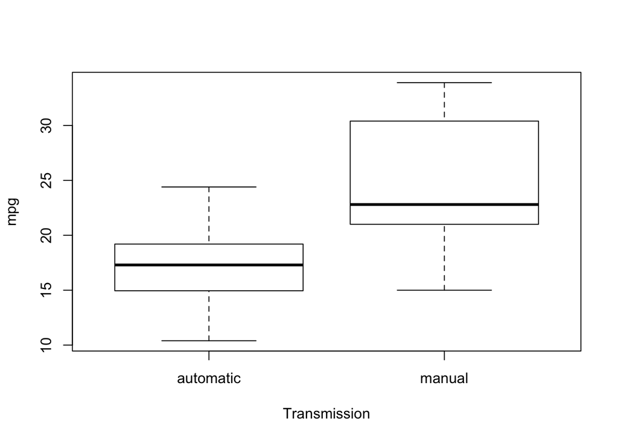

```r
boxplot(mpg~am,data=mtcars,names=c("automatic","manual"),ylab="mpg",xlab="Transmission")
```

o también como un gráfico de barras con errors

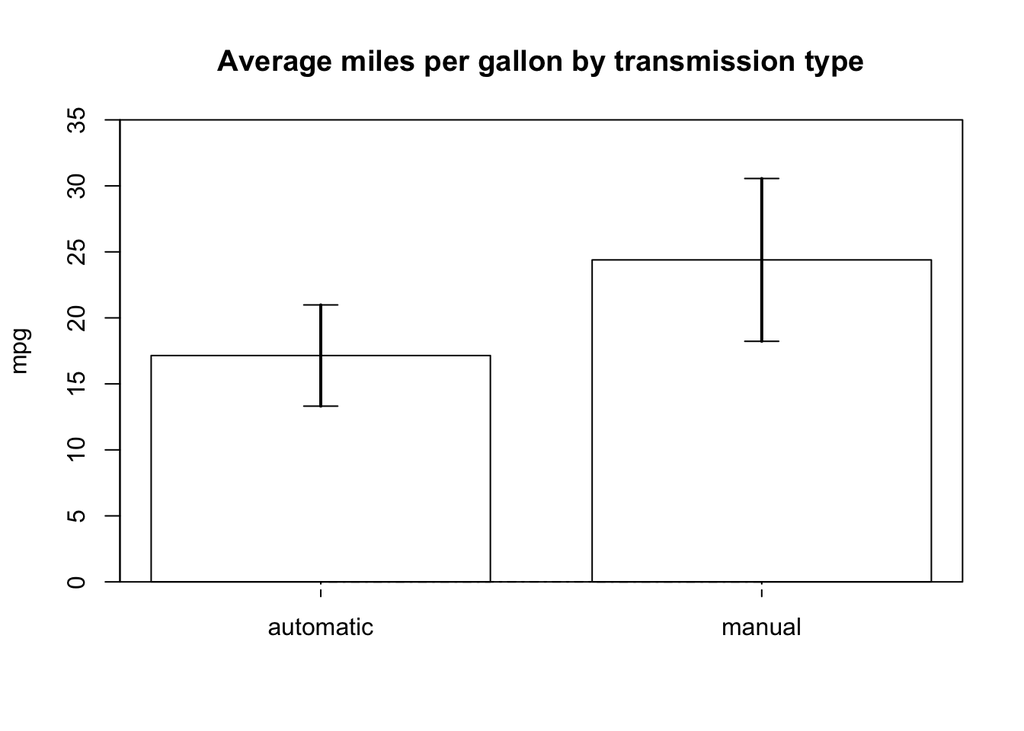

```r
##### Step 1. reorganize the data in a correct format for statistical analysis
aggmpg <- tapply(mtcars$mpg, mtcars$am, mean, na.rm = TRUE)
sdmpg <- tapply(mtcars$mpg, mtcars$am, sd, na.rm = TRUE)
aggam <- unique(factor(c("automatic", "manual")))
##### Step 2. Plot a barchart
barmpg <- barplot(aggmpg, names = aggam, ylim = c(0, 35), main = paste("Average miles per gallon by transmission type"),
    space = 0.3, axes = TRUE, axis.lty = 10, col = "white", ylab = "mpg")
# put the plot in a box
box()
# plot the vertical lines of the error bars
segments(barmpg, aggmpg - sdmpg, barmpg, aggmpg + sdmpg, lwd = 2)
# now plot the horizontal bounds for the error bars the lower bar
segments(barmpg - 0.05, aggmpg - sdmpg, barmpg + 0.05, aggmpg - sdmpg, lwd = 1)
# the upper bar
segments(barmpg - 0.05, aggmpg + sdmpg, barmpg + 0.05, aggmpg + sdmpg, lwd = 1)
```

Hacemos algunas pruebas estadísticas para comparar el mpg entre autos automáticos y manuales.

La primera es un $t$-test, suponiendo que los datos de kilometraje tienen una distribución normal. El resultado de la prueba demuestra claramente que los coches de transmisión manual son más eficientes que los automóviles de transmisión automática (millas por galón: 24,39 frente a 17,15).

```r
t.test(mpg ~ factor(am), data = mtcars)
```

```
##
##  Welch Two Sample t-test
##
## data:  mpg by factor(am)
## t = -3.7671, df = 18.332, p-value = 0.001374
## alternative hypothesis: true difference in means is not equal to 0
## 95 percent confidence interval:
##  -11.280194  -3.209684
## sample estimates:
## mean in group 0 mean in group 1
##        17.14737        24.39231
```

Sin embargo, la hipótesis de normalidad podría ser bastante fuerte, dado el hecho de que no sabemos las verdaderas distribuciones subyacentes de los datos de `mpg`. Además, el número de puntos de datos no es lo suficientemente grande como para aplicar el teorema del límite central. Por lo tanto, una prueba más conservadora sería la prueba de Wilcoxon, con la hipótesis nula de que los datos de consumo de gas de las transmisiones manuales y automáticas son de poblaciones idénticas.

```r
wilcox.test(mpg ~ am, data = mtcars)
```

```
##
##  Wilcoxon rank sum test with continuity correction
##
## data:  mpg by am
## W = 42, p-value = 0.001871
## alternative hypothesis: true location shift is not equal to 0
```

Un test no paramétrico de Wilcoxon también rechaza la hipótesis nula de que los datos de kilometraje de las transmisiones manuales y automáticas son de la misma población (lo que indica una diferencia).

## 1.8 Contrastes de hipótesis

Deseamos probar una hipótesis nula ($H_0$) con una hipótesis alternativa ($H_1$) usando un conjunto de datos. Las dos hipótesis especifican dos modelos estadísticos para el proceso que produjo los datos. La hipótesis alternativa es lo que esperamos que sea cierto si la hipótesis nula es falsa. No podemos probar que la hipótesis alternativa es verdadera, pero podemos demostrar que la alternativa es mucho más plausible que la hipótesis nula dada a los datos. Esta demostración se expresa generalmente en términos de una probabilidad (un valor de P) que cuantifica la fuerza de la evidencia contra la hipótesis nula en favor de la alternativa.

Nos preguntamos si los datos parecen ser consistentes con la hipótesis nula o si es sería poco probable que obtuviera datos de este tipo si la hipótesis nula fuera verídica, que al menos una de las dos hipótesis es verdadera. Tratamos esta pregunta calculando la valor de una estadística de prueba, es decir, una función de valor real particular de los datos. Decidir si el valor de la estadística de prueba es consistente con la hipótesis nula, necesitamos saber qué muestreo a esperar en nuestra estadística de prueba si la hipótesis nula es verdadera. En otra las palabras, necesitamos conocer la distribución nula, la distribución del estadístico de prueba cuando la hipótesis nula es verdadera. En muchas aplicaciones, la estadística de prueba se define de modo que su valor nulo distribución es una distribución “nombrada” para la cual las tablas son ampliamente accesibles; por ejemplo, el distribución normal estándar, la distribución binomial con $n = 100$ y $p = 1/2$, la distribución $t$ con 4 grados de libertad, la distribución chi-cuadrada con 23 grados de libertad, la distribución F con 2 y 20 grados de libertad.

Ahora, dado el valor de la estadística de prueba (un número), y la distribución nula de la prueba estadística (una distribución teórica generalmente representada por una densidad de probabilidad), queremos ver si la estadística de la prueba está en el medio de la distribución (consistente con el nulo hipótesis) o en una cola de la distribución (haciendo que la hipótesis alternativa parezca más plausible). A veces queremos considerar la cola derecha, a veces la mano izquierda cola, ya veces ambas colas, dependiendo de cómo la estadística de prueba y la hipótesis alternativa están definidos. Supongamos que los grandes valores positivos de la estadística de prueba parecen más plausibles bajo la hipótesis alternativa que bajo la hipótesis nula. Entonces queremos una medida de qué tan lejos está nuestra estadística de prueba en la cola derecha de la distribución nula. El $p$-valor proporciona una medida de esta distancia. El $p$-valor (en esta situación) es la probabilidad de que derecha de nuestra estadística de prueba calculada usando la distribución nula. Cuanto más lejos de la prueba estadística está en la cola, menor es el P-valor, y más fuerte es la evidencia contra el nulo hipótesis a favor de la alternativa.

El $p$-valor puede interpretarse en términos de una hipotética repetición del estudio. Suponer la hipótesis nula es verdadera y se obtiene un nuevo conjunto de datos independientemente del primer conjunto de datos pero utilizando el mismo procedimiento de muestreo. Si el nuevo conjunto de datos se utiliza para calcular un nuevo valor de la estadística de prueba (misma fórmula pero nuevos datos), ¿cuál es la probabilidad de que el nuevo valor será más lejos en la cola (suponiendo una prueba de una cola) que el valor original? este es el $p$-valor.

El $p$-valor suele interpretarse incorrectamente como la probabilidad de que la hipótesis nula sea cierto. Trata de no cometer este error. En una interpretación frecuentista de la probabilidad, no hay nada al azar si la hipótesis es verdadera, la aleatoriedad está en el proceso generando los datos. Se puede interpretar “la probabilidad de que la hipótesis nula sea verdadera” usando probabilidad subjetiva, una medida de la creencia de uno de que la hipótesis nula es verdadera. Se puede calcular esta probabilidad subjetiva especificando una probabilidad previa (creencia subjetiva antes de mirar los datos) que la hipótesis nula es verdadera, y luego usar los datos y la modelo para actualizar la probabilidad subjetiva de uno. Esto se denomina enfoque bayesiano porque El teorema de Bayes se utiliza para actualizar las probabilidades subjetivas para reflejar nueva información.

Al notificar un $p$-valor a personas que no están familiarizadas con las estadísticas, a menudo es lenguaje descriptivo para indicar la fuerza de la evidencia.

| $p$-value | Interpretacion |
| --- | --- |
| $p> 0.10$ | Ninguna evidencia contra la hipótesis nula. Los datos parecen ser coherentes con la hipótesis nula |
| $0.05<p<0.10$ | Evidencia débil contra la hipótesis nula en favor de la alternativa |
| $0.01<p<0.05$ | Evidencia moderada contra la hipótesis nula a favor de la alternativa. |
| $0.001<p<0.01$ | Evidencia fuerte contra la hipótesis nula en favor de la alternativa |
| $p<0.001$ | Evidencia muy fuerte contra la hipótesis nula en favor de la alternativa |

En el uso de este tipo de lenguaje, se debe tener en cuenta la diferencia entre significación y significado práctico. En un estudio grande se puede obtener un pequeño $p$-valor aunque la magnitud del efecto que se está probando es demasiado pequeña para ser importante (véase la discusión del poder abajo). Es una buena idea apoyar un $p$-valor con una confianza intervalo para el parámetro que se está probando.